# R实战第二版笔记-广义线性模型+因子模型

Studennt. LI Junjie

Dongbei University of Finance & Economics

2020-07-09

# 1 加载经常用的R包

```r
library(pacman)
# 读数据
p_load(readxl,writexl,data.table,openxlsx,haven,rvest)
```

```r
# 数据探索
p_load(tidyverse,DT,skimr,DataExplorer,explore,vtable,stringr,kableExtra,lubridate)
```

```r
# 模型
p_load(grf,glmnet,caret,tidytext,fpp2,forecast,car,tseries,hdm,tidymodels,broom)
```

```r
# 可视化
p_load(patchwork,ggrepel,ggcorrplot,gghighlight,ggthemes,shiny)
```

```r
# 其它常用包
p_load(magrittr,listviewer,devtools,here,janitor,reticulate,jsonlite)
```

# 2 Logistic 回归

## 2.1 建立logistic模型

当通过一系列连续型和/或类别型预测变量来预测二值型结果变量时，Logistic回归是一个非常有用的工具。以AER包中的**数据框Affairs**为例，我们将通过探究婚外情的数据来阐述Logistic回归的过程。首次使用该数据前，请确保已下载和安装了此软件包（使用`install.packages("AER")`）

```r
library(AER)
data("Affairs")
```

```r
Affairs %>% summary()
```

```
##     affairs          gender         age         yearsmarried    children
##  Min.   : 0.000   female:315   Min.   :17.50   Min.   : 0.125   no :171
##  1st Qu.: 0.000   male  :286   1st Qu.:27.00   1st Qu.: 4.000   yes:430
##  Median : 0.000                Median :32.00   Median : 7.000
##  Mean   : 1.456                Mean   :32.49   Mean   : 8.178
##  3rd Qu.: 0.000                3rd Qu.:37.00   3rd Qu.:15.000
##  Max.   :12.000                Max.   :57.00   Max.   :15.000
##  religiousness     education       occupation        rating
##  Min.   :1.000   Min.   : 9.00   Min.   :1.000   Min.   :1.000
##  1st Qu.:2.000   1st Qu.:14.00   1st Qu.:3.000   1st Qu.:3.000
##  Median :3.000   Median :16.00   Median :5.000   Median :4.000
##  Mean   :3.116   Mean   :16.17   Mean   :4.195   Mean   :3.932
##  3rd Qu.:4.000   3rd Qu.:18.00   3rd Qu.:6.000   3rd Qu.:5.000
##  Max.   :5.000   Max.   :20.00   Max.   :7.000   Max.   :5.000
```

```r
Affairs %>% DT::datatable()
```

|  | affairs | gender | age | yearsmarried | children | religiousness | education | occupation | rating |
| --- | --- | --- | --- | --- | --- | --- | --- | --- | --- |
| 4 | 0 | male | 37 | 10 | no | 3 | 18 | 7 | 4 |
| 5 | 0 | female | 27 | 4 | no | 4 | 14 | 6 | 4 |
| 11 | 0 | female | 32 | 15 | yes | 1 | 12 | 1 | 4 |
| 16 | 0 | male | 57 | 15 | yes | 5 | 18 | 6 | 5 |
| 23 | 0 | male | 22 | 0.75 | no | 2 | 17 | 6 | 3 |
| 29 | 0 | female | 32 | 1.5 | no | 2 | 17 | 5 | 5 |
| 44 | 0 | female | 22 | 0.75 | no | 2 | 12 | 1 | 3 |
| 45 | 0 | male | 57 | 15 | yes | 2 | 14 | 4 | 4 |
| 47 | 0 | female | 32 | 15 | yes | 4 | 16 | 1 | 2 |
| 49 | 0 | male | 22 | 1.5 | no | 4 | 14 | 4 | 5 |

[output cut: 591 more lines]

```r
skimr::skim(Affairs)
```

Table 2.1: Data summary

| Name | Affairs |
| --- | --- |
| Number of rows | 601 |
| Number of columns | 9 |
| _______________________ |  |
| Column type frequency: |  |
| factor | 2 |
| numeric | 7 |
| ________________________ |  |
| Group variables | None |

**Variable type: factor**

| skim_variable | n_missing | complete_rate | ordered | n_unique | top_counts |
| --- | --- | --- | --- | --- | --- |
| gender | 0 | 1 | FALSE | 2 | fem: 315, mal: 286 |
| children | 0 | 1 | FALSE | 2 | yes: 430, no: 171 |

**Variable type: numeric**

| skim_variable | n_missing | complete_rate | mean | sd | p0 | p25 | p50 | p75 | p100 | hist |
| --- | --- | --- | --- | --- | --- | --- | --- | --- | --- | --- |
| affairs | 0 | 1 | 1.46 | 3.30 | 0.00 | 0 | 0 | 0 | 12 | ▇▁▁▁▁ |
| age | 0 | 1 | 32.49 | 9.29 | 17.50 | 27 | 32 | 37 | 57 | ▃▇▂▂▁ |
| yearsmarried | 0 | 1 | 8.18 | 5.57 | 0.12 | 4 | 7 | 15 | 15 | ▆▅▃▃▇ |
| religiousness | 0 | 1 | 3.12 | 1.17 | 1.00 | 2 | 3 | 4 | 5 | ▂▇▆▇▃ |
| education | 0 | 1 | 16.17 | 2.40 | 9.00 | 14 | 16 | 18 | 20 | ▁▂▆▇▇ |
| occupation | 0 | 1 | 4.19 | 1.82 | 1.00 | 3 | 5 | 6 | 7 | ▅▂▂▇▆ |
| rating | 0 | 1 | 3.93 | 1.10 | 1.00 | 3 | 4 | 5 | 5 | ▁▂▃▇▇ |

```r
Affairs %>% as_tibble() %>%
  mutate(affairs = if_else(affairs > 0,1,0)) %>%
  mutate(affairs = factor(affairs,
                          levels = c(0,1),
                          labels = c("No","yes"))) -> Affairs
```

```r
fit.full <- glm(
  affairs ~ gender + age + yearsmarried + children +
    religiousness + education + occupation + rating,
  data = Affairs,
  family = binomial()
)
fit.full %>% stargazer::stargazer(type = "text")
```

```
##
## =============================================
##                       Dependent variable:
##                   ---------------------------
##                             affairs
## ---------------------------------------------
## gendermale                   0.280
##                             (0.239)
##
## age                        -0.044**
##                             (0.018)
##
## yearsmarried               0.095***
##                             (0.032)
##
## childrenyes                  0.398
##                             (0.292)
##
## religiousness              -0.325***
##                             (0.090)
##
## education                    0.021
##                             (0.051)
##
## occupation                   0.031
##                             (0.072)
##
## rating                     -0.468***
##                             (0.091)
##
## Constant                     1.377
##                             (0.888)
##
## ---------------------------------------------
## Observations                  601
## Log Likelihood             -304.755
## Akaike Inf. Crit.           627.510
## =============================================
## Note:             *p<0.1; **p<0.05; ***p<0.01
```

```r
summary(fit.full)
```

```
##
## Call:
## glm(formula = affairs ~ gender + age + yearsmarried + children +
##     religiousness + education + occupation + rating, family = binomial(),
##     data = Affairs)
##
## Deviance Residuals:
##     Min       1Q   Median       3Q      Max
## -1.5713  -0.7499  -0.5690  -0.2539   2.5191
##
## Coefficients:
##               Estimate Std. Error z value Pr(>|z|)
## (Intercept)    1.37726    0.88776   1.551 0.120807
## gendermale     0.28029    0.23909   1.172 0.241083
## age           -0.04426    0.01825  -2.425 0.015301 *
## yearsmarried   0.09477    0.03221   2.942 0.003262 **
## childrenyes    0.39767    0.29151   1.364 0.172508
## religiousness -0.32472    0.08975  -3.618 0.000297 ***
## education      0.02105    0.05051   0.417 0.676851
## occupation     0.03092    0.07178   0.431 0.666630
## rating        -0.46845    0.09091  -5.153 2.56e-07 ***
## ---
## Signif. codes:  0 '***' 0.001 '**' 0.01 '*' 0.05 '.' 0.1 ' ' 1
##
## (Dispersion parameter for binomial family taken to be 1)
##
##     Null deviance: 675.38  on 600  degrees of freedom
## Residual deviance: 609.51  on 592  degrees of freedom
## AIC: 627.51
##
## Number of Fisher Scoring iterations: 4
```

从回归系数的p值（最后一栏）可以看到，性别、是否有孩子、学历和职业对方程的贡献都不显著（你无法拒绝参数为0的假设）。去除这些变量重新拟合模型，检验新模型是否拟合得好

```r
fit.reduced <- glm(
  affairs ~ age + yearsmarried + religiousness + rating,
  data = Affairs,
  family = binomial()
)
fit.reduced %>% summary()
```

```
##
## Call:
## glm(formula = affairs ~ age + yearsmarried + religiousness +
##     rating, family = binomial(), data = Affairs)
##
## Deviance Residuals:
##     Min       1Q   Median       3Q      Max
## -1.6278  -0.7550  -0.5701  -0.2624   2.3998
##
## Coefficients:
##               Estimate Std. Error z value Pr(>|z|)
## (Intercept)    1.93083    0.61032   3.164 0.001558 **
## age           -0.03527    0.01736  -2.032 0.042127 *
## yearsmarried   0.10062    0.02921   3.445 0.000571 ***
## religiousness -0.32902    0.08945  -3.678 0.000235 ***
## rating        -0.46136    0.08884  -5.193 2.06e-07 ***
## ---
## Signif. codes:  0 '***' 0.001 '**' 0.01 '*' 0.05 '.' 0.1 ' ' 1
##
## (Dispersion parameter for binomial family taken to be 1)
##
##     Null deviance: 675.38  on 600  degrees of freedom
## Residual deviance: 615.36  on 596  degrees of freedom
## AIC: 625.36
##
## Number of Fisher Scoring iterations: 4
```

由于两模型嵌套（fit.reduced是fit.full的一个子集），你可以使用`anova()函数`对它们进行比较，对于广义线性回归，可用卡方检验

```r
anova(fit.reduced, fit.full, test="Chisq")
```

|  | Resid. Df | Resid. Dev | Df | Deviance | Pr(>Chi) |
| --- | --- | --- | --- | --- | --- |
| 1 | 596 | 615.3578 | NA | NA | NA |
| 2 | 592 | 609.5104 | 4 | 5.847418 | 0.2108367 |

## 2.2 解释模型参数

```r
coef(fit.reduced)
```

```
##   (Intercept)           age  yearsmarried religiousness        rating
##    1.93083017   -0.03527112    0.10062274   -0.32902386   -0.46136144
```

在Logistic回归中，响应变量是Y=1的对数优势比（log）。回归系数的含义是*当其他预测变量不变时，一单位预测变量的变化可引起的响应变量对数优势比的变化*。

由于对数优势比解释性差，你可对结果进行指数化

```r
exp(coef(fit.reduced))
```

```
##   (Intercept)           age  yearsmarried religiousness        rating
##     6.8952321     0.9653437     1.1058594     0.7196258     0.6304248
```

可以看到*婚龄增加一年*，婚外情的*优势比将乘以1.106*（保持年龄、宗教信仰和婚姻评定不变）；相反，*年龄增加一岁*，婚外情的的*优势比则乘以0.965*。因此，随着婚龄的增加和年龄、宗教信仰与婚姻评分的降低，婚外情优势比将上升。因为预测变量不能等于0，截距项在此处没有什么特定含义。

如果有需要，你还可使用confint()函数获取系数的置信区间。例如， exp(confint(fit.reduced))可在优势比尺度上得到系数95%的置信区间。

最后，预测变量一单位的变化可能并不是我们最想关注的。对于二值型Logistic回归，某预测变量n单位的变化引起的*较高值上优势比的变化*为`exp(βj)^n`，它反映的信息可能更为重要。比如，保持其他预测变量不变，婚龄增加一年，婚外情的优势比将乘以1.106，而如果婚龄增加10年，优势比将乘以1.106^10，即2.7。

## 2.3 评价预测变量对结果概率的影响

对于我们大多数人来说，以概率的方式思考比使用优势比更直观。使用predict()函数，可以观察某个预测变量在各个水平时对结果概率的影响。首先创建一个包含你感兴趣预测变量值的虚拟数据集，然后对该数据集使用predict()函数，以预测这些值的结果概率。

现在我们使用该方法评价婚姻评分对婚外情概率的影响。首先，创建一个虚拟数据集，设定年龄、婚龄和宗教信仰为它们的均值，婚姻评分的范围为1～5。

```r
testdata <-
  data.frame(
    rating = c(1, 2, 3, 4, 5),
    age = mean(Affairs$age),
    yearsmarried = mean(Affairs$yearsmarried),
    religiousness = mean(Affairs$religiousness)
  )
testdata
```

| rating | age | yearsmarried | religiousness |
| --- | --- | --- | --- |
| 1 | 32.48752 | 8.177696 | 3.116473 |
| 2 | 32.48752 | 8.177696 | 3.116473 |
| 3 | 32.48752 | 8.177696 | 3.116473 |
| 4 | 32.48752 | 8.177696 | 3.116473 |
| 5 | 32.48752 | 8.177696 | 3.116473 |

```r
testdata$prob <- predict(fit.reduced,
                         newdata=testdata,
                         type="response")
testdata
```

| rating | age | yearsmarried | religiousness | prob |
| --- | --- | --- | --- | --- |
| 1 | 32.48752 | 8.177696 | 3.116473 | 0.5302296 |
| 2 | 32.48752 | 8.177696 | 3.116473 | 0.4157377 |
| 3 | 32.48752 | 8.177696 | 3.116473 | 0.3096712 |
| 4 | 32.48752 | 8.177696 | 3.116473 | 0.2204547 |
| 5 | 32.48752 | 8.177696 | 3.116473 | 0.1513079 |

```r
testdata <- data.frame(
  rating = mean(Affairs$rating),
  age = seq(17, 57, 10),
  yearsmarried = mean(Affairs$yearsmarried),
  religiousness = mean(Affairs$religiousness)
)
testdata
```

| rating | age | yearsmarried | religiousness |
| --- | --- | --- | --- |
| 3.93178 | 17 | 8.177696 | 3.116473 |
| 3.93178 | 27 | 8.177696 | 3.116473 |
| 3.93178 | 37 | 8.177696 | 3.116473 |
| 3.93178 | 47 | 8.177696 | 3.116473 |
| 3.93178 | 57 | 8.177696 | 3.116473 |

```r
testdata$prop <- predict.glm(object = fit.reduced,newdata = testdata,
                            type = "response")
testdata
```

| rating | age | yearsmarried | religiousness | prop |
| --- | --- | --- | --- | --- |
| 3.93178 | 17 | 8.177696 | 3.116473 | 0.3350834 |
| 3.93178 | 27 | 8.177696 | 3.116473 | 0.2615373 |
| 3.93178 | 37 | 8.177696 | 3.116473 | 0.1992953 |
| 3.93178 | 47 | 8.177696 | 3.116473 | 0.1488796 |
| 3.93178 | 57 | 8.177696 | 3.116473 | 0.1094738 |

此处可以看到，当其他变量不变，*年龄从17增加到57时，婚外情的概率将从0.34降低到0.11。*利用该方法，你可探究每一个预测变量对结果概率的影响。

```r
testdata <- data.frame(
  rating = mean(Affairs$rating),
  age = mean(Affairs$age),
  yearsmarried = seq(0,15,1),
  religiousness = mean(Affairs$religiousness)
)
testdata
```

| rating | age | yearsmarried | religiousness |
| --- | --- | --- | --- |
| 3.93178 | 32.48752 | 0 | 3.116473 |
| 3.93178 | 32.48752 | 1 | 3.116473 |
| 3.93178 | 32.48752 | 2 | 3.116473 |
| 3.93178 | 32.48752 | 3 | 3.116473 |
| 3.93178 | 32.48752 | 4 | 3.116473 |
| 3.93178 | 32.48752 | 5 | 3.116473 |
| 3.93178 | 32.48752 | 6 | 3.116473 |
| 3.93178 | 32.48752 | 7 | 3.116473 |
| 3.93178 | 32.48752 | 8 | 3.116473 |
| 3.93178 | 32.48752 | 9 | 3.116473 |

[output cut: 6 more lines]

```r
testdata$prop <- predict.glm(object = fit.reduced,newdata = testdata,
                            type = "response")
testdata
```

| rating | age | yearsmarried | religiousness | prop |
| --- | --- | --- | --- | --- |
| 3.93178 | 32.48752 | 0 | 3.116473 | 0.1136079 |
| 3.93178 | 32.48752 | 1 | 3.116473 | 0.1241413 |
| 3.93178 | 32.48752 | 2 | 3.116473 | 0.1355022 |
| 3.93178 | 32.48752 | 3 | 3.116473 | 0.1477273 |
| 3.93178 | 32.48752 | 4 | 3.116473 | 0.1608502 |
| 3.93178 | 32.48752 | 5 | 3.116473 | 0.1748996 |
| 3.93178 | 32.48752 | 6 | 3.116473 | 0.1898984 |
| 3.93178 | 32.48752 | 7 | 3.116473 | 0.2058626 |
| 3.93178 | 32.48752 | 8 | 3.116473 | 0.2227997 |
| 3.93178 | 32.48752 | 9 | 3.116473 | 0.2407080 |

[output cut: 6 more lines]

## 2.4 过度离势

抽样于二项分布的数据的期望方差是σ2=nπ(1–π)，n为观测数，π为属于Y=1组的概率。所谓过度离势，即观测到的响应变量的方差大于期望的二项分布的方差。过度离势会导致奇异的标准误检验和不精确的显著性检验。

当出现过度离势时，仍可使用glm()函数拟合Logistic回归，但此时需要将二项分布改为类二项分布（quasibinomial distribution）。

```r
deviance(fit.reduced)/df.residual(fit.reduced)
```

```
## [1] 1.03248
```

它非常接近于1，表明没有过度离势。

你还可以对**过度离势进行检验**。为此，你需要拟合模型两次，第一次使用family= inomial“，第二次使用family=”quasibinomial"。假设第一次glm()返回对象记为fit， 二次返回对象记为fit.od，那么：

```r
pchisq(summary(fit.od)$dispersion * fit$df.residual,
       fit$df.residual,
       lower = F)
```

# 3 主成分分析和因子分析

## 3.1 R中的主成分和因子分析

- 数据预处理
- 选择因子模型
- 判断要选择的主成分/因子数目
- 选择主成分/因子
- 旋转主成分/因子
- 解释结果
- 计算主成分或因子得分

```r
library(psych)
```

## 3.2 主成分分析

### 3.2.1 判断主成分的个数

```
## Parallel analysis suggests that the number of factors =  NA  and the number of components =  1
```

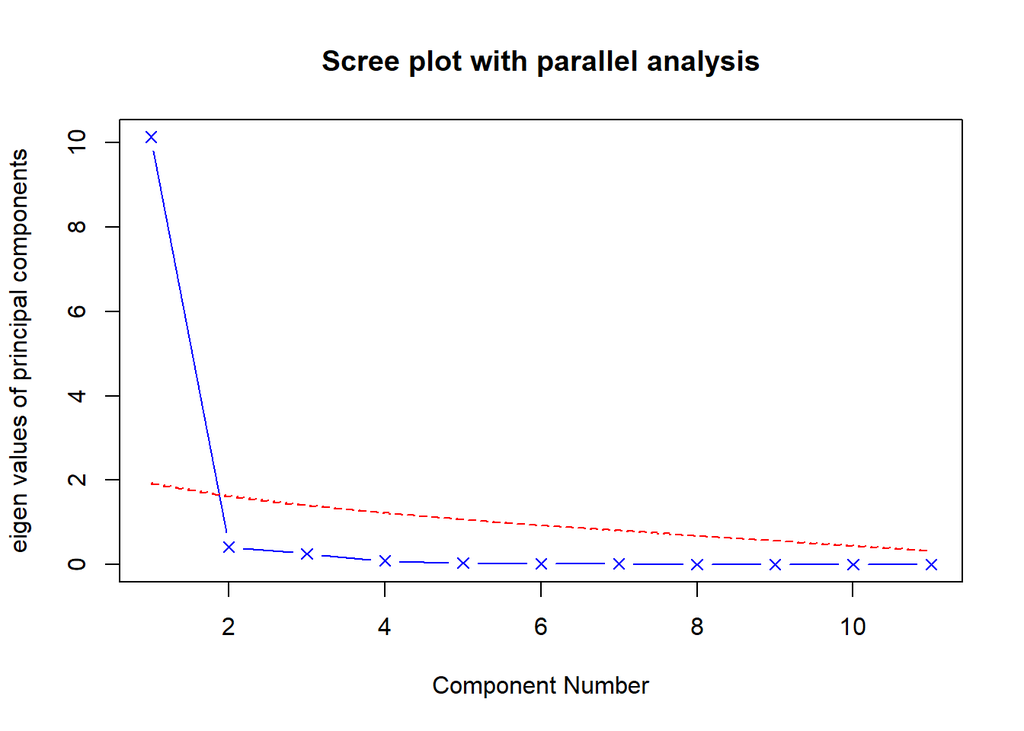

```r
psych::fa.parallel(USJudgeRatings[,-1],fa = "pc",n.iter = 100,
                   show.legend = FALSE,
                   main = "Scree plot with parallel analysis")
```

### 3.2.2 提取主成分

```r
pc <- psych::principal(USJudgeRatings[,-1],nfactors = 1)
pc
```

```
## Principal Components Analysis
## Call: psych::principal(r = USJudgeRatings[, -1], nfactors = 1)
```

```
## Standardized loadings (pattern matrix) based upon correlation matrix
##       PC1   h2     u2 com
## INTG 0.92 0.84 0.1565   1
## DMNR 0.91 0.83 0.1663   1
## DILG 0.97 0.94 0.0613   1
## CFMG 0.96 0.93 0.0720   1
## DECI 0.96 0.92 0.0763   1
## PREP 0.98 0.97 0.0299   1
## FAMI 0.98 0.95 0.0469   1
## ORAL 1.00 0.99 0.0091   1
## WRIT 0.99 0.98 0.0196   1
## PHYS 0.89 0.80 0.2013   1
## RTEN 0.99 0.97 0.0275   1
##
##                  PC1
## SS loadings    10.13
## Proportion Var  0.92
##
## Mean item complexity =  1
## Test of the hypothesis that 1 component is sufficient.
##
## The root mean square of the residuals (RMSR) is  0.04
##  with the empirical chi square  6.21  with prob <  1
##
## Fit based upon off diagonal values = 1
```

让我们再来看看第二个例子，它的结果不止一个主成分。**Harman23.cor数据集**包含305个女孩的8个身体测量指标。本例中，数据集由变量的相关系数组成，而不是原始数据集

```r
Harman23.cor
```

```
## $cov
##                height arm.span forearm lower.leg weight bitro.diameter
## height          1.000    0.846   0.805     0.859  0.473          0.398
## arm.span        0.846    1.000   0.881     0.826  0.376          0.326
## forearm         0.805    0.881   1.000     0.801  0.380          0.319
## lower.leg       0.859    0.826   0.801     1.000  0.436          0.329
## weight          0.473    0.376   0.380     0.436  1.000          0.762
## bitro.diameter  0.398    0.326   0.319     0.329  0.762          1.000
## chest.girth     0.301    0.277   0.237     0.327  0.730          0.583
## chest.width     0.382    0.415   0.345     0.365  0.629          0.577
##                chest.girth chest.width
## height               0.301       0.382
## arm.span             0.277       0.415
## forearm              0.237       0.345
## lower.leg            0.327       0.365
## weight               0.730       0.629
## bitro.diameter       0.583       0.577
## chest.girth          1.000       0.539
## chest.width          0.539       1.000
##
## $center
## [1] 0 0 0 0 0 0 0 0
##
## $n.obs
## [1] 305
```

```r
fa.parallel(
  Harman23.cor$cov,
  n.obs = 302,
  fa = "pc",
  n.iter = 100,
  show.legend = FALSE,
  main = "Scree plot with parallel analysis"
)
```

```
## Parallel analysis suggests that the number of factors =  NA  and the number of components =  2
```

```r
pc <- psych::principal(Harman23.cor$cov, nfactors=2, rotate="none")
pc
```

```
## Principal Components Analysis
## Call: psych::principal(r = Harman23.cor$cov, nfactors = 2, rotate = "none")
```

```
## Standardized loadings (pattern matrix) based upon correlation matrix
##                 PC1   PC2   h2    u2 com
## height         0.86 -0.37 0.88 0.123 1.4
## arm.span       0.84 -0.44 0.90 0.097 1.5
## forearm        0.81 -0.46 0.87 0.128 1.6
## lower.leg      0.84 -0.40 0.86 0.139 1.4
## weight         0.76  0.52 0.85 0.150 1.8
## bitro.diameter 0.67  0.53 0.74 0.261 1.9
## chest.girth    0.62  0.58 0.72 0.283 2.0
## chest.width    0.67  0.42 0.62 0.375 1.7
##
##                        PC1  PC2
## SS loadings           4.67 1.77
## Proportion Var        0.58 0.22
## Cumulative Var        0.58 0.81
## Proportion Explained  0.73 0.27
## Cumulative Proportion 0.73 1.00
##
## Mean item complexity =  1.7
## Test of the hypothesis that 2 components are sufficient.
##
## The root mean square of the residuals (RMSR) is  0.05
##
## Fit based upon off diagonal values = 0.99
```

```r
rc <- principal(Harman23.cor$cov, nfactors=2, rotate="varimax")
rc
```

```
## Principal Components Analysis
## Call: principal(r = Harman23.cor$cov, nfactors = 2, rotate = "varimax")
```

```
## Standardized loadings (pattern matrix) based upon correlation matrix
##                 RC1  RC2   h2    u2 com
## height         0.90 0.25 0.88 0.123 1.2
## arm.span       0.93 0.19 0.90 0.097 1.1
## forearm        0.92 0.16 0.87 0.128 1.1
## lower.leg      0.90 0.22 0.86 0.139 1.1
## weight         0.26 0.88 0.85 0.150 1.2
## bitro.diameter 0.19 0.84 0.74 0.261 1.1
## chest.girth    0.11 0.84 0.72 0.283 1.0
## chest.width    0.26 0.75 0.62 0.375 1.2
##
##                        RC1  RC2
## SS loadings           3.52 2.92
## Proportion Var        0.44 0.37
## Cumulative Var        0.44 0.81
## Proportion Explained  0.55 0.45
## Cumulative Proportion 0.55 1.00
##
## Mean item complexity =  1.1
## Test of the hypothesis that 2 components are sufficient.
##
## The root mean square of the residuals (RMSR) is  0.05
##
## Fit based upon off diagonal values = 0.99
```

### 3.2.3 获取主成分得分

```r
USJudgeRatings
```

|  | CONT | INTG | DMNR | DILG | CFMG | DECI | PREP | FAMI | ORAL | WRIT | PHYS | RTEN |
| --- | --- | --- | --- | --- | --- | --- | --- | --- | --- | --- | --- | --- |
| AARONSON,L.H. | 5.7 | 7.9 | 7.7 | 7.3 | 7.1 | 7.4 | 7.1 | 7.1 | 7.1 | 7.0 | 8.3 | 7.8 |
| ALEXANDER,J.M. | 6.8 | 8.9 | 8.8 | 8.5 | 7.8 | 8.1 | 8.0 | 8.0 | 7.8 | 7.9 | 8.5 | 8.7 |
| ARMENTANO,A.J. | 7.2 | 8.1 | 7.8 | 7.8 | 7.5 | 7.6 | 7.5 | 7.5 | 7.3 | 7.4 | 7.9 | 7.8 |
| BERDON,R.I. | 6.8 | 8.8 | 8.5 | 8.8 | 8.3 | 8.5 | 8.7 | 8.7 | 8.4 | 8.5 | 8.8 | 8.7 |
| BRACKEN,J.J. | 7.3 | 6.4 | 4.3 | 6.5 | 6.0 | 6.2 | 5.7 | 5.7 | 5.1 | 5.3 | 5.5 | 4.8 |
| BURNS,E.B. | 6.2 | 8.8 | 8.7 | 8.5 | 7.9 | 8.0 | 8.1 | 8.0 | 8.0 | 8.0 | 8.6 | 8.6 |
| CALLAHAN,R.J. | 10.6 | 9.0 | 8.9 | 8.7 | 8.5 | 8.5 | 8.5 | 8.5 | 8.6 | 8.4 | 9.1 | 9.0 |
| COHEN,S.S. | 7.0 | 5.9 | 4.9 | 5.1 | 5.4 | 5.9 | 4.8 | 5.1 | 4.7 | 4.9 | 6.8 | 5.0 |
| DALY,J.J. | 7.3 | 8.9 | 8.9 | 8.7 | 8.6 | 8.5 | 8.4 | 8.4 | 8.4 | 8.5 | 8.8 | 8.8 |
| DANNEHY,J.F. | 8.2 | 7.9 | 6.7 | 8.1 | 7.9 | 8.0 | 7.9 | 8.1 | 7.7 | 7.8 | 8.5 | 7.9 |

[output cut: 33 more lines]

```r
pc <- psych::principal(USJudgeRatings[,-1], nfactors=1, score=TRUE)
head(pc$scores)
```

```
##                       PC1
## AARONSON,L.H.  -0.1857981
## ALEXANDER,J.M.  0.7469865
## ARMENTANO,A.J.  0.0704772
## BERDON,R.I.     1.1358765
## BRACKEN,J.J.   -2.1586211
## BURNS,E.B.      0.7669406
```

```r
rc <- psych::principal(Harman23.cor$cov, nfactors=2, rotate="varimax")
round(unclass(rc$weights), 2)
```

```
##                  RC1   RC2
## height          0.28 -0.05
## arm.span        0.30 -0.08
## forearm         0.30 -0.09
## lower.leg       0.28 -0.06
## weight         -0.06  0.33
## bitro.diameter -0.08  0.32
## chest.girth    -0.10  0.34
## chest.width    -0.04  0.27
```

$$PC2 = -0.05*height - 0.08*arm.span - 0.09*forearm - 0.06*lower.leg +
\\ 0.33*weight + 0.32*bitro.diameter + 0.34*chest.girth + 0.27*chest.width$$

许多数据分析师都对PCA和EFA存有或多或少的疑惑。一个是历史原因，它可以追溯到一 个叫作Little Jiffy的软件（不是玩笑）。 Little Jiffy是因子分析早期最流行的一款软件，默认做主成分分析，选用**方差极大旋转法，提取特征值大于1的成分**。这款软件应用得如此广泛，以至于许多社会科学家都默认它与EFA同义。许多后来的统计软件包在它们的EFA程序中都默认如此处理。

如果你的目标是寻求可解释观测变量的潜在隐含变量，可使用因子分析，这正是下一节的 主题。

## 3.3 探索性因子分析

**EFA的目标**是通过发掘隐藏在数据下的一组较少的、更为基本的无法观测的变量，来解释一组可观测变量的相关性。这些虚拟的、无法观测的变量称作因子。（每个因子被认为可解释多个观测变量间共有的方差，因此准确来说，它们应该称作公共因子。）

```r
covariances <- ability.cov$cov
correlations <- cov2cor(covariances)
correlations
```

```
##           general   picture    blocks      maze   reading     vocab
## general 1.0000000 0.4662649 0.5516632 0.3403250 0.5764799 0.5144058
## picture 0.4662649 1.0000000 0.5724364 0.1930992 0.2629229 0.2392766
## blocks  0.5516632 0.5724364 1.0000000 0.4450901 0.3540252 0.3564715
## maze    0.3403250 0.1930992 0.4450901 1.0000000 0.1839645 0.2188370
## reading 0.5764799 0.2629229 0.3540252 0.1839645 1.0000000 0.7913779
## vocab   0.5144058 0.2392766 0.3564715 0.2188370 0.7913779 1.0000000
```

因为要寻求用来解释数据的潜在结构，可使用EFA方法。与使用PCA相同，下一步工作为判 断需要提取几个因子

### 3.3.1 判断需提取的公共因子数

```
## Parallel analysis suggests that the number of factors =  2  and the number of components =  1
```

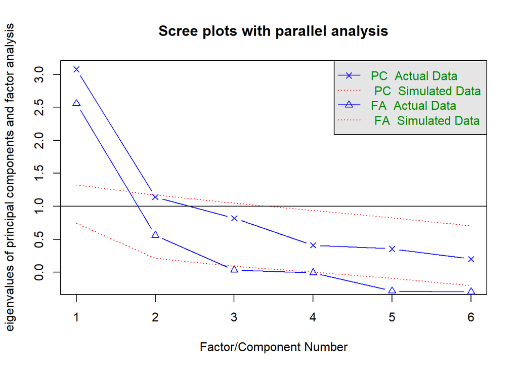

```r
fa.parallel(
  correlations,
  n.obs = 112,
  fa = "both",
  n.iter = 100,
  main = "Scree plots with parallel analysis"
)
```

### 3.3.2 提取公共因子

```r
fa <- fa(correlations, nfactors=2, rotate="none", fm="pa")
fa
```

```
## Factor Analysis using method =  pa
## Call: fa(r = correlations, nfactors = 2, rotate = "none", fm = "pa")
```

```
## Standardized loadings (pattern matrix) based upon correlation matrix
##          PA1   PA2   h2    u2 com
## general 0.75  0.07 0.57 0.432 1.0
## picture 0.52  0.32 0.38 0.623 1.7
## blocks  0.75  0.52 0.83 0.166 1.8
## maze    0.39  0.22 0.20 0.798 1.6
## reading 0.81 -0.51 0.91 0.089 1.7
## vocab   0.73 -0.39 0.69 0.313 1.5
##
##                        PA1  PA2
## SS loadings           2.75 0.83
## Proportion Var        0.46 0.14
## Cumulative Var        0.46 0.60
## Proportion Explained  0.77 0.23
## Cumulative Proportion 0.77 1.00
##
## Mean item complexity =  1.5
## Test of the hypothesis that 2 factors are sufficient.
##
## The degrees of freedom for the null model are  15  and the objective function was  2.48
## The degrees of freedom for the model are 4  and the objective function was  0.07
##
## The root mean square of the residuals (RMSR) is  0.03
## The df corrected root mean square of the residuals is  0.06
##
## Fit based upon off diagonal values = 0.99
## Measures of factor score adequacy
##                                                    PA1  PA2
## Correlation of (regression) scores with factors   0.96 0.92
## Multiple R square of scores with factors          0.93 0.84
## Minimum correlation of possible factor scores     0.86 0.68
```

### 3.3.3 因子旋转

```r
fa.varimax <- fa(correlations, nfactors=2, rotate="varimax", fm="pa")
fa.varimax
```

```
## Factor Analysis using method =  pa
## Call: fa(r = correlations, nfactors = 2, rotate = "varimax", fm = "pa")
```

```
## Standardized loadings (pattern matrix) based upon correlation matrix
##          PA1  PA2   h2    u2 com
## general 0.49 0.57 0.57 0.432 2.0
## picture 0.16 0.59 0.38 0.623 1.1
## blocks  0.18 0.89 0.83 0.166 1.1
## maze    0.13 0.43 0.20 0.798 1.2
## reading 0.93 0.20 0.91 0.089 1.1
## vocab   0.80 0.23 0.69 0.313 1.2
##
##                        PA1  PA2
## SS loadings           1.83 1.75
## Proportion Var        0.30 0.29
## Cumulative Var        0.30 0.60
## Proportion Explained  0.51 0.49
## Cumulative Proportion 0.51 1.00
##
## Mean item complexity =  1.3
## Test of the hypothesis that 2 factors are sufficient.
##
## The degrees of freedom for the null model are  15  and the objective function was  2.48
## The degrees of freedom for the model are 4  and the objective function was  0.07
##
## The root mean square of the residuals (RMSR) is  0.03
## The df corrected root mean square of the residuals is  0.06
##
## Fit based upon off diagonal values = 0.99
## Measures of factor score adequacy
##                                                    PA1  PA2
## Correlation of (regression) scores with factors   0.96 0.92
## Multiple R square of scores with factors          0.91 0.85
## Minimum correlation of possible factor scores     0.82 0.71
```

用斜交旋转提取因子

```r
fa.promax <- psych::fa(correlations, nfactors=2, rotate="promax", fm="pa")
fa.promax
```

```
## Factor Analysis using method =  pa
## Call: psych::fa(r = correlations, nfactors = 2, rotate = "promax",
##     fm = "pa")
```

```
## Standardized loadings (pattern matrix) based upon correlation matrix
##           PA1   PA2   h2    u2 com
## general  0.37  0.48 0.57 0.432 1.9
## picture -0.03  0.63 0.38 0.623 1.0
## blocks  -0.10  0.97 0.83 0.166 1.0
## maze     0.00  0.45 0.20 0.798 1.0
## reading  1.00 -0.09 0.91 0.089 1.0
## vocab    0.84 -0.01 0.69 0.313 1.0
##
##                        PA1  PA2
## SS loadings           1.83 1.75
## Proportion Var        0.30 0.29
## Cumulative Var        0.30 0.60
## Proportion Explained  0.51 0.49
## Cumulative Proportion 0.51 1.00
##
##  With factor correlations of
##      PA1  PA2
## PA1 1.00 0.55
## PA2 0.55 1.00
##
## Mean item complexity =  1.2
## Test of the hypothesis that 2 factors are sufficient.
##
## The degrees of freedom for the null model are  15  and the objective function was  2.48
## The degrees of freedom for the model are 4  and the objective function was  0.07
##
## The root mean square of the residuals (RMSR) is  0.03
## The df corrected root mean square of the residuals is  0.06
##
## Fit based upon off diagonal values = 0.99
## Measures of factor score adequacy
##                                                    PA1  PA2
## Correlation of (regression) scores with factors   0.97 0.94
## Multiple R square of scores with factors          0.93 0.88
## Minimum correlation of possible factor scores     0.86 0.77
```

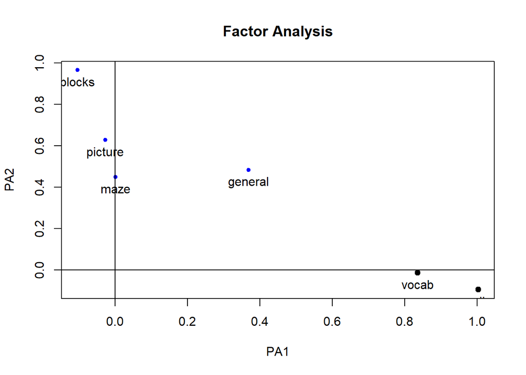

```r
factor.plot(fa.promax, labels=rownames(fa.promax$loadings))
```

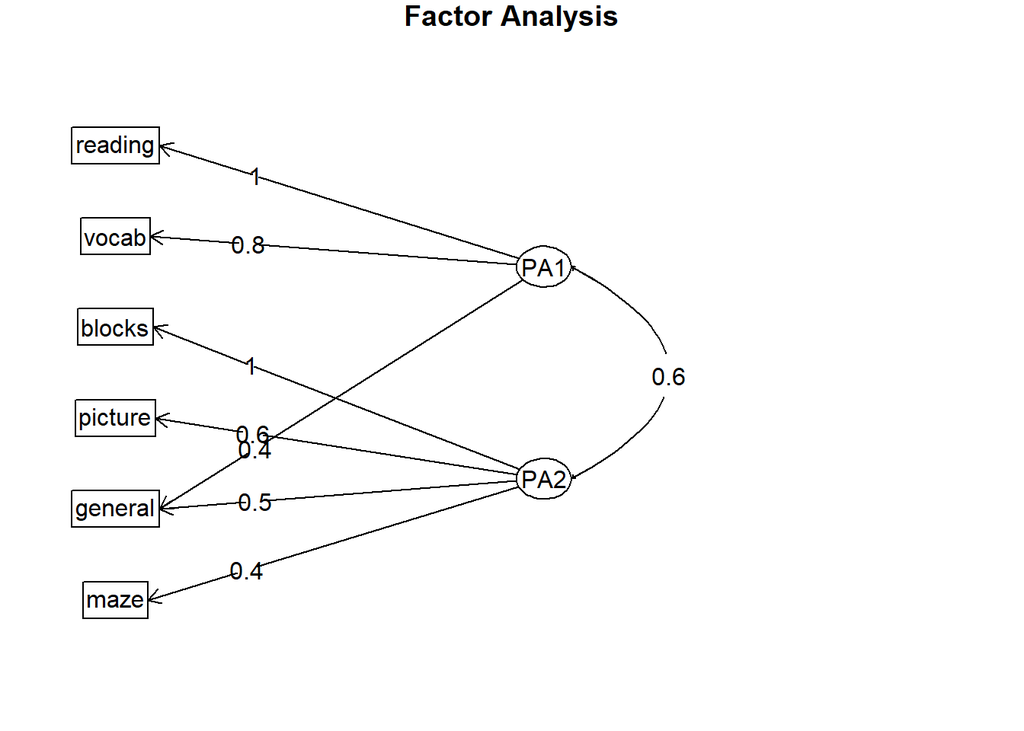

```r
fa.diagram(fa.promax, simple=FALSE)
```

### 3.3.4 因子得分

```r
fa.promax$weights
```

```
##                PA1        PA2
## general 0.07836571 0.21091463
## picture 0.02000694 0.09038071
## blocks  0.03662858 0.70209400
## maze    0.02700266 0.03453381
## reading 0.74276722 0.03012597
## vocab   0.17683183 0.03583324
```

与可精确计算的主成分得分不同，因子得分只是估计得到的。它的估计方法有多种， `fa()函数`使用的是回归方法。若想更多地了解因子得分，可参阅DiStefano、 Zhu和Mîndrilă的“Understanding and Using Factor Scores: Considerations for the Applied Researcher”（2009）。

## 3.4 其他潜变量模型

## 3.5 小结

本章，我们主要学习了**主成分分析（PCA）**和**探索性因子分析（EFA）**两种方法。 PCA在数据降维方面非常有用，它能用一组较少的不相关变量来替代大量相关变量，进而简化分析过程。EFA包含很多方法，可用来发现一组可观测变量背后潜在的或无法观测的结构（因子）。

与PCA综合数据和降低维度的目标不同，EFA是假设生成工具，它在帮助理解众多变量间的关系时非常有用，常用于社会科学的理论研究。

虽然两种方法表面上有许多相似之处，但也有重要的差异。本章中，我们探究了这两种方法的模型，学习了**判断需提取的主成分/因子数的方法**、**提取主成分/因子**和**通过旋转增强解释力的方法**，以及**获得主成分/因子得分**的技巧。

# 4 时间序列分析

## 4.1 生成时间序列对象

| 函数 | 程序包 | 用途 |
| --- | --- | --- |
| ts() | stats | 生成时序对象 |
| plot() | graphics | 画出时间序列的折线图 |
| start() | stats | 返回时间序列的开始时间 |
| end() | stats | 返回时间序列的结束时间 |
| frequency() | stats | 返回时间序列中时间点的个数 |
| window() | stats | 对时序对象取子集 |
| ma() | forecast | 拟合一个简单的移动平均模型 |
| stl() | stats | 用LOESS光滑将时序分解为季节项、趋势项和随机项 |
| monthplot() | stats | 画出时序中的季节项 |
| seasonplot() | forecast | 生成季节图 |
| HoltWinters() | stats | 拟合指数平滑模型 |
| forecast() | forecast | 预测时序的未来值 |
| accuracy() | forecast | 返回时序的拟合优度度量 |
| ets() | forecast | 拟合指数平滑模型，同时也可以自动选取最优模型 |
| lag() | stats | 返回取过指定滞后项后的时序 |
| Acf() | forecast | 估计自相关函数 |
| Pacf() | forecast | 估计偏自相关函数 |
| diff() | base | 返回取过滞后项和（或）差分后的序列 |
| ndiffs() | forecast | 找到最优差分次数以移除序列中的趋势项 |
| adf.test() | tseries | 对序列做ADF检验以判断其是否平稳 |
| arima() | stats | 拟合ARIMA模型 |
| Box.test() | stats | 进行Ljung-Box检验以判断模型的残差是否独立 |
| bds.test() | tseries | 进行BDS检验以判断序列中的随机变量是否服从独立同分布 |
| auto.arima() | forecast | 自动选择ARIMA模型 |